# Trivago Hits Model

Longhow Lam

3/29/2019

[figure not shown]

# 1 Introduction

This R Markdown document presents the result of the Trivago Hits model. A copy of this R Markdown can also be found on my [GitHub repository](https://github.com/longhowlam/HitsModel)

## 1.1 Background

- row_num: a number uniquely identifying each row.
- locale: the platform of the session.
- day_of_week: Mon-Fri, the day of the week of the session.
- hour_of_day: 00-23, the hour of the day of the session.
- agent_id: the device used for the session.
- entry_page: describes the landing page of the session.
- path_id_set: shows all the locations that were visited during the session.
- traffic_type: indicates the channel the user cane through eg. search engine, email, …
- session_duration: the duration in seconds of the session.
- hits: the number of interactions with the trivago page during the session.

## 1.2 Task

Note that the column “hits” has missing values. Use the data provided to build a model that predicts the number of hits per session, depending on the given parameters. Refer to the deliverables section to check how to hand in your solution.

## 1.3 Evaluation

Your predictions will be evaluated by the root mean square error.

$$error = \sqrt{\frac{\sum_{i=1}^{N} ( predictedHits_i - observedHits_i)^2}{N}}$$

# 2 Import data

The libraries that we need in this analysis in R

```r
library(tidyverse)
library(skimr)
library(arules)
library(arulesViz)
library(h2o)
library(plotly)
```

First let us import the data, and create a variable with the number of locations visited. The path_id_set might be empty (missing) we then assume zero locations visited!

Now have a very first glance at the data with skimr too see for example if there are a lot of missing values.

```r
skim(hitsData)
```

```
## Skim summary statistics
##  n obs: 988681
##  n variables: 11
##
## ── Variable type:character ───────────────────────────────────────────────────────────────────────────────────────────────────────────────
##      variable missing complete      n min max empty n_unique
##      agent_id       0   988681 988681   1   2     0       16
##   day_of_week       0   988681 988681   6   9     0        7
##    entry_page       0   988681 988681   4   4     0      147
##        locale       0   988681 988681   2   2     0        6
##   path_id_set    4889   983792 988681   1 810     0   151267
##  traffic_type       0   988681 988681   1   2     0        7
##
## ── Variable type:numeric ─────────────────────────────────────────────────────────────────────────────────────────────────────────────────
##           variable missing complete      n      mean        sd p0    p25    p50    p75   p100     hist
##               hits  369446   619235 988681     18.21     39.1   1      3      7     19   4174 ▇▁▁▁▁▁▁▁
##        hour_of_day       0   988681 988681     13.2       6.72  0      8     14     19     23 ▅▃▃▅▆▇▇▆
##         nlocations       0   988681 988681      2.07      0.98  0      2      2      2    133 ▇▁▁▁▁▁▁▁
##            row_num       0   988681 988681 494341    285407.77  1 247171 494341 741511 988681 ▇▇▇▇▇▇▇▇
##  session_durantion     668   988013 988681    492.92   1921.52  0      4     57    324  86219 ▇▁▁▁▁▁▁▁
```

# 3 Data for model building

Create the data set for building the model.

```r
hitsModelData = hitsData %>%
  filter(
    !is.na(hits),
    !is.na(session_durantion)
  )
```

## 3.1 Hits vs duration and number of locations

Look at how session duration and number of location visited affect the number of hits. We break up session duration in intervals and we look at log of number of hits. They are too large to see anything on a normal plot

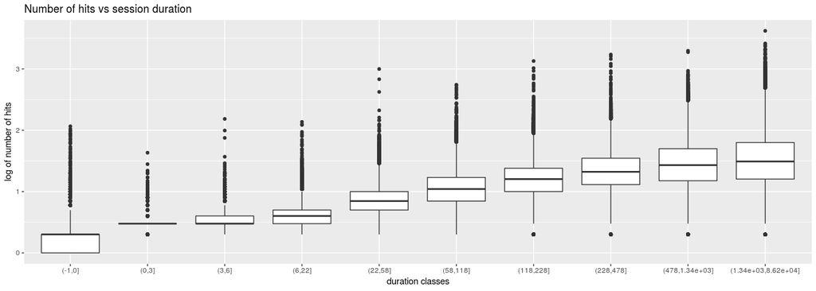

```r
## take 10% percentiles as breaks
p10 = quantile(hitsModelData$session_durantion, probs = (0:10)/10)

hitsModelData %>%
  mutate(
    durationClass = cut(session_durantion, breaks = c(-1,unique(p10)))
  ) %>%
  ggplot(
    aes(durationClass, log10(hits))
  ) +
  geom_boxplot() +
  labs(
    x = "duration classes",
    y = "log of number of hits",
    title = "Number of hits vs session duration"
  )
```

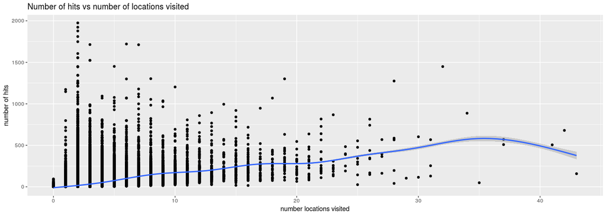

```r
hitsModelData %>%
  filter(
    hits < 2000,
    nlocations < 50
  ) %>%
  ggplot(
    aes(nlocations, hits)
  ) +
  geom_point() +
  geom_smooth() +
  labs(
    x = "number locations visited",
    y = "number of hits",
    title = "Number of hits vs number of locations visited"
  )
```

## 3.2 Variable importance

To get an idea of the predictive power of the individual inputs we fit a random forest and look at the variable importance plot. Ignore the `path_id_set` variable for now in the variable importance plot, there are too many unique possibilities. We deal with it later.

My go to package for machine learning in R is h2o.

```r
## character columns need to be factor columns in h2o.
hitsModelData = hitsModelData %>%
  mutate_if(is.character, as.factor)

## bring data to h20
hitsInH2o = as.h2o(hitsModelData)

## train forest and show variable importance plot
out = h2o.randomForest(
  x = c(2,3,4,5,6,8,9,11),
  y = 10,
  hitsInH2o
)
```

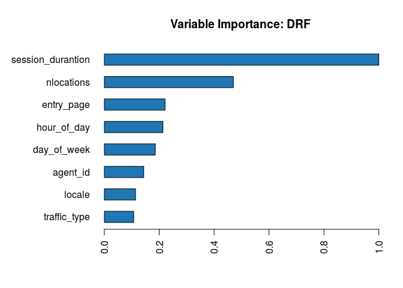

```r
h2o.varimp_plot(out)
```

## 3.3 Associations Rules Mining (ARM)

ARM, is also known as market basket analysis in a supermarket setting.

The `path_id_set` column contains the location id’s visited in a session. With ARM it is interesting to see which locations (also called items in ARM terminology) are often visited together in one session. This can be learned by applying the so-called apriori algorithm to all the sessions that we have. The result will be a set of rules learned from the data in the form:

- IF {location 4321} THEN likely also {location 6544}.
- IF {location 12345} THEN likely also {location 98765}.

This is an interesting exercise on its own right. What we want do here however, is to see if any of the location id’s (items) can be linked with large or small number of hits. Therefore we bucketize the number hits in buckets, and add them to the path_id_set so that these “hit buckets” also become items. When we now run the apriori algorithm and see if the algorithm find rules of the form:

- IF {location 54332} THEN likely {high number of hits}
- IF {location 43210} THEN likely {low number of hits}

For each rule that the algorithm will find, some interesting statistics are provided as well. The support, confidence and lift, they will help us to evaluate a rule. For example, the lift will tell us how much more likely it is to see a high number of hits given a location is visited, compared to when the location was not visited.

```r
## take 10% percentiles as breaks for the hits
p10 = quantile(hitsModelData$hits, probs = (0:9)/9)

# Create hitbuckes named: H1, H2, up until H10 for the bucket with the most number of hits
# write out this basket data to file
basketData = hitsModelData %>%
  mutate(
    hitsBuckets = sprintf(
      "H%02d",
      as.integer( cut(hits, breaks = c(0, p10)) )
    ),
    baskets = paste( hitsBuckets, path_id_set, sep = ";")
  ) %>%
  select(baskets)

write_csv(basketData, "marketbaskets.csv")

# using read.transactions in the arules package we can read the file
# so that it becomes a proper transaction object for the aprior algorithm
paths = read.transactions("marketbaskets.csv", format = "basket", skip=1, TRUE, sep=";")
```

Now the object `paths` is a formal arules transaction object from which we can run the apriori algorithm. But first let’s see some frequencies of the individual items.

```r
print(paths)
```

```
## transactions in sparse format with
##  618820 transactions (rows) and
##  28226 items (columns)
```

```r
freqs = sort(itemFrequency(paths, type="absolute"), decreasing = TRUE)
freqs_df = data.frame(location = names(freqs), frequency = freqs)
head(freqs_df, 15)
```

```
##       location frequency
## 0            0    559954
## H03        H03     98267
## H06        H06     73299
## H09        H09     68549
## H10        H10     68291
## H07        H07     65892
## H04        H04     65157
## H08        H08     62578
## H02        H02     50627
## H05        H05     37135
## H01        H01     29025
## 38715    38715     13210
## 34741    34741      9835
## 34812    34812      9385
## 78506    78506      5910
```

We that there are 618820 transactions, this is just the number of sessions with a non missing number of hits, in total there are 28226 items (28216 locations visited and 10 hit buckets). We see that after location `0`, the location `38715` is the most visited location in this data.

Now lets generate association rules, we restrict ourselves to rules of the form {A} –> {B} (max length = 2).

```r
locationRules = apriori(
  paths,
  parameter = list(
    conf = 0.0001, supp = 0.0001,  target = "rules", maxlen = 2
  )
)
```

```
## Apriori
##
## Parameter specification:
##  confidence minval smax arem  aval originalSupport maxtime support minlen maxlen target   ext
##       1e-04    0.1    1 none FALSE            TRUE       5   1e-04      1      2  rules FALSE
##
## Algorithmic control:
##  filter tree heap memopt load sort verbose
##     0.1 TRUE TRUE  FALSE TRUE    2    TRUE
##
## Absolute minimum support count: 61
##
## set item appearances ...[0 item(s)] done [0.00s].
## set transactions ...[28226 item(s), 618820 transaction(s)] done [0.50s].
## sorting and recoding items ... [1711 item(s)] done [0.01s].
## creating transaction tree ... done [0.38s].
## checking subsets of size 1 2 done [0.02s].
## writing ... [8539 rule(s)] done [0.01s].
## creating S4 object  ... done [0.14s].
```

```r
print(locationRules)
```

```
## set of 8539 rules
```

```r
inspect( sort(locationRules, by = "lift")[1:15])
```

```
##      lhs      rhs   support      confidence lift     count
## [1]  {170} => {70}  0.0001357422 0.4640884  1940.454  84
## [2]  {70}  => {170} 0.0001357422 0.5675676  1940.454  84
## [3]  {480} => {316} 0.0001745257 0.7248322  1868.919 108
## [4]  {316} => {480} 0.0001745257 0.4500000  1868.919 108
## [5]  {420} => {480} 0.0001034226 0.4076433  1693.006  64
## [6]  {480} => {420} 0.0001034226 0.4295302  1693.006  64
## [7]  {318} => {316} 0.0001163505 0.6101695  1573.271  72
## [8]  {316} => {318} 0.0001163505 0.3000000  1573.271  72
## [9]  {318} => {400} 0.0001906855 1.0000000  1531.733 118
## [10] {400} => {318} 0.0001906855 0.2920792  1531.733 118
## [11] {480} => {400} 0.0002310850 0.9597315  1470.052 143
## [12] {400} => {480} 0.0002310850 0.3539604  1470.052 143
## [13] {400} => {316} 0.0003603633 0.5519802  1423.235 223
## [14] {316} => {400} 0.0003603633 0.9291667  1423.235 223
## [15] {440} => {400} 0.0001018067 0.9130435  1398.539  63
```

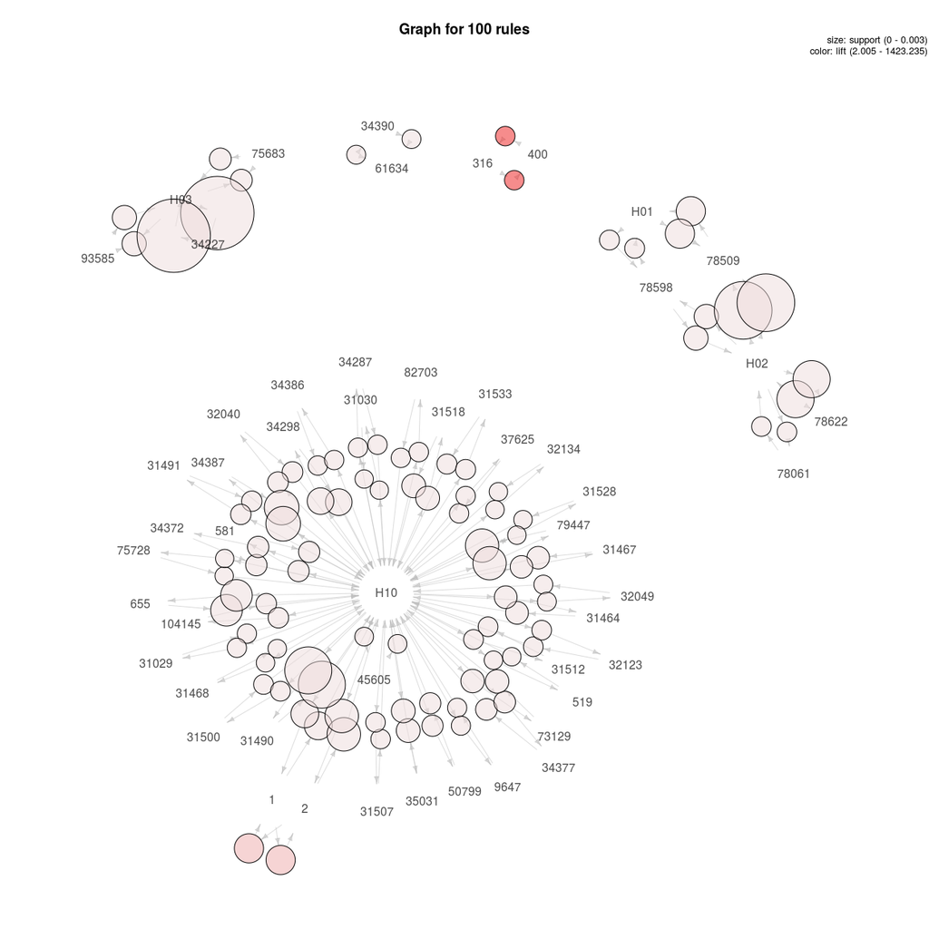

```r
plot(subset(locationRules, lift > 2), method="graph")
```

Now look at rules where hit buckets are involved. First look at locations found in rules leading to high hit buckets (H9 and H10).

```r
HighHitsRules = arules::subset(locationRules, rhs %pin% c("H09","H10") & lift > 1.1)
inspect(HighHitsRules[1:20])
```

```
##      lhs         rhs   support      confidence lift     count
## [1]  {42692}  => {H09} 0.0001228144 0.2459547  2.220334 76
## [2]  {73995}  => {H09} 0.0001034226 0.1782730  1.609343 64
## [3]  {33608}  => {H09} 0.0001098866 0.1789474  1.615431 68
## [4]  {94722}  => {H09} 0.0001034226 0.1729730  1.561498 64
## [5]  {51502}  => {H09} 0.0001082706 0.1704835  1.539024 67
## [6]  {628998} => {H09} 0.0001389742 0.3038869  2.743312 86
## [7]  {3578}   => {H09} 0.0001082706 0.1845730  1.666216 67
## [8]  {79178}  => {H09} 0.0001098866 0.1752577  1.582124 68
## [9]  {44371}  => {H09} 0.0001082706 0.1925287  1.738036 67
## [10] {35012}  => {H09} 0.0001001907 0.1438515  1.298607 62
## [11] {34775}  => {H09} 0.0001098866 0.1566820  1.414433 68
## [12] {32136}  => {H09} 0.0001050386 0.1473923  1.330571 65
## [13] {73566}  => {H09} 0.0001163505 0.1628959  1.470528 72
## [14] {94375}  => {H09} 0.0001131185 0.1794872  1.620305 70
## [15] {34311}  => {H09} 0.0001001907 0.1438515  1.298607 62
## [16] {34330}  => {H09} 0.0001082706 0.1466083  1.323494 67
## [17] {73265}  => {H09} 0.0001018067 0.1632124  1.473386 63
## [18] {1113}   => {H09} 0.0001260463 0.1691974  1.527414 78
## [19] {31825}  => {H09} 0.0001486700 0.2053571  1.853843 92
## [20] {93757}  => {H09} 0.0001357422 0.1862528  1.681380 84
```

```r
plotly_arules(
  HighHitsRules,
  max = 4000,
  measure = c("support", "lift"),
  shading = "conf"
)  %>%
  layout(title = 'locations found that lead to high number of hits')
```

```
## To reduce overplotting, jitter is added! Use jitter = 0 to prevent jitter.
```

[interactive chart not shown]

We can also look at rules that do not lead to high number of hits, where the lift is smaller than 1.

```r
AntiHighHitsRules = arules::subset(locationRules, rhs %pin% c("H09","H10") & lift < 0.9)
```

Do the same with low hit buckets.

```r
LowHitsRules = arules::subset(locationRules, rhs %pin% c("H01","H02", "H03") & lift > 1.1 )
AntiLowHitsRules = arules::subset(locationRules, rhs %pin% c("H01","H02", "H03") & lift < 0.9 )
```

# 4 Create the predictive model with h2o

## 4.1 Create Additional features based on locations

From the rules learned in the previous section we can now extract location ID’s that are likely to lead to high number of hits/interactions. We create additional features in the data set that will indicate how many of these locations are visited during a session.

```r
highloc = DATAFRAME(HighHitsRules) %>%
  select(LHS) %>%
  mutate(
    locations = as.character(LHS) %>%
      str_replace_all("\\{","") %>%
      str_replace("\\}","")
  ) %>%  .$locations

antihighloc = DATAFRAME(AntiHighHitsRules) %>%
  select(LHS) %>%
  mutate(
    locations = as.character(LHS) %>%
      str_replace_all("\\{","") %>%
      str_replace("\\}","")
  ) %>%  .$locations

lowloc = DATAFRAME(LowHitsRules) %>%
  select(LHS) %>%
  mutate(
    locations = as.character(LHS) %>%
      str_replace_all("\\{","") %>%
      str_replace("\\}","")
  ) %>%  .$locations

antilowloc = DATAFRAME(AntiLowHitsRules) %>%
  select(LHS) %>%
  mutate(
    locations = as.character(LHS) %>%
      str_replace_all("\\{","") %>%
      str_replace("\\}","")
  ) %>%  .$locations
```

Now create new columns in the modeling data set by counting how many times we see a “high” or “low” location in the path_id_set.

```r
hitsModelData2 = hitsModelData %>%
  rowwise() %>%
  mutate(
    test =  path_id_set %>% str_split(";"),
    high_hit_locs = sum( !is.na(match( highloc, test)) ),
    anti_high_hit_locs = sum( !is.na(match( antihighloc, test)) ),
    low_hit_locs = sum( !is.na(match( lowloc, test)) ),
    anti_low_hit_locs = sum( !is.na(match( antilowloc, test)) )
  ) %>%
  select(-test)
```

A quick inspection shows that indeed if sessions contain 1 or more “high locations” have on average more hits.

```r
hitsModelData2 %>%
  group_by(high_hit_locs) %>%
  summarise(n = n(), mean_hits = mean(hits))
```

```
## # A tibble: 24 x 3
##    high_hit_locs      n mean_hits
##            <int>  <int>     <dbl>
##  1             0 379857      14.4
##  2             1 220397      20.9
##  3             2  15149      53.2
##  4             3   2412      94.4
##  5             4    559     133.
##  6             5    242     174.
##  7             6     96     226.
##  8             7     47     225.
##  9             8     28     249.
## 10             9     11     265.
## # … with 14 more rows
```

## 4.2 Use automl to Build the predictive model

Now we can build a model with the extra “location” features. We are going to use `automl` in the h2o package, it trains and cross-validates a Random Forest, an Extremely-Randomized Forest, a random grid of Gradient Boosting Machines (GBMs), a random grid of Deep Neural Nets, and then trains a Stacked Ensemble using all of the models.

We let it run for 1 hour, which is the default.

```r
hitsModelData3 = hitsModelData2 %>% as.data.frame()
hitsModelData3 = hitsModelData3 %>%  mutate_if(is.character, as.factor)
hitsInH2o = as.h2o(hitsModelData3)

TT = h2o.splitFrame(hitsInH2o)
out = h2o.automl(
  x = c(2,3,4,5,6,8,9,11,12,13,14,15),
  y = 10,
  training_frame = TT[[1]],
  validation_frame = TT[[2]],
)

## save winner model to disk
winner = out@leader
h2o.saveModel(winner, "winnerModel")
```

Lets have look at the leader board. A stacked ensemble of all models is the one with the lowest RMSE. The RMSE is 31.93287 reported on cross-validation data (5-fold cross-validation on training data (Metrics computed for combined holdout predictions). And the RMSE reported on the separate holdout test set is 30.18.

```r
leaderboard = readRDS( "leaderboard.RDs")
leaderboard
```

```
##                                               model_id mean_residual_deviance     rmse      mse       mae     rmsle
## 1     StackedEnsemble_AllModels_AutoML_20190331_173503               1019.708 31.93287 1019.708 10.206714        NA
## 2  StackedEnsemble_BestOfFamily_AutoML_20190331_173503               1021.050 31.95388 1021.050 10.227886        NA
## 3            GBM_grid_1_AutoML_20190331_173503_model_2               1023.860 31.99781 1023.860 10.158500        NA
## 4                         GBM_5_AutoML_20190331_173503               1026.556 32.03991 1026.556 10.237342        NA
## 5                         GBM_2_AutoML_20190331_173503               1028.720 32.07367 1028.720 10.204200        NA
## 6                     XGBoost_1_AutoML_20190331_173503               1031.789 32.12147 1031.789 10.317634        NA
## 7                         GBM_3_AutoML_20190331_173503               1031.902 32.12323 1031.902 10.216996        NA
## 8                     XGBoost_2_AutoML_20190331_173503               1032.895 32.13868 1032.895 10.116638        NA
## 9                         GBM_1_AutoML_20190331_173503               1034.959 32.17079 1034.959 10.225058        NA
## 10                        GBM_4_AutoML_20190331_173503               1040.768 32.26093 1040.768 10.211072        NA
## 11       XGBoost_grid_1_AutoML_20190331_173503_model_2               1043.044 32.29620 1043.044  9.769121 0.5145837
## 12           GBM_grid_1_AutoML_20190331_173503_model_3               1044.584 32.32002 1044.584 10.670166        NA
## 13       XGBoost_grid_1_AutoML_20190331_173503_model_1               1046.017 32.34218 1046.017 10.151592        NA
## 14                    XGBoost_3_AutoML_20190331_173503               1046.445 32.34880 1046.445 10.283555        NA
## 15           GBM_grid_1_AutoML_20190331_173503_model_5               1057.255 32.51546 1057.255 10.714684        NA
## 16                        DRF_1_AutoML_20190331_173503               1060.609 32.56699 1060.609 10.299478 0.5316735
## 17               DeepLearning_1_AutoML_20190331_173503               1062.991 32.60354 1062.991 11.072996        NA
## 18  DeepLearning_grid_1_AutoML_20190331_173503_model_1               1079.422 32.85456 1079.422 10.563307        NA
## 19                        XRT_1_AutoML_20190331_173503               1175.659 34.28789 1175.659 10.772433 0.5433221
## 20           GLM_grid_1_AutoML_20190331_173503_model_1               1192.080 34.52651 1192.080 13.000265        NA
## 21  DeepLearning_grid_1_AutoML_20190331_173503_model_2               1380.960 37.16127 1380.960 22.768917        NA
## 22           GBM_grid_1_AutoML_20190331_173503_model_4               1477.844 38.44273 1477.844 12.614631        NA
## 23           GBM_grid_1_AutoML_20190331_173503_model_1               1773.352 42.11118 1773.352 14.341057        NA
```

# 5 Use champion model to predict hits

We can load the saved champion model to score the submission data set. I.e. the data in the input file for which there are missing values in the hits column.

```r
champion = h2o.loadModel("winnerModel/StackedEnsemble_AllModels_AutoML_20190331_173503")

submissionData = hitsData %>%
  filter(
    is.na(hits)
  )

## create the extra "location" features

submissionData = submissionData %>%
  rowwise() %>%
  mutate(
    test =  path_id_set %>% str_split(";"),
    high_hit_locs = sum( !is.na(match( highloc, test)) ),
    anti_high_hit_locs = sum( !is.na(match( antihighloc, test)) ),
    low_hit_locs = sum( !is.na(match( lowloc, test)) ),
    anti_low_hit_locs = sum( !is.na(match( antilowloc, test)) )
  ) %>%
  select(-test)

## transform character type to factor and upload to h2o for scoring
submissionData = submissionData %>%
  as.data.frame() %>%
  mutate_if(is.character, as.factor)

submInH2o = as.h2o(submissionData)

predictions = h2o.predict(champion, submInH2o)

final_submissionData = bind_cols(
  submissionData %>% select(row_num) ,
  predictions %>% as.data.frame()
) %>% rename(hits = predict)

write_csv(final_submissionData, "submission.csv")
```